# Coursera’s Statistical Inference Final Project Part - 2, Tooth Growth Data Analysis

Jorge Mendoza

August 11, 2017

## Overview

On this report we will provide the results of the statistical inference over the ToothGrowth data of the R data set.

This package describes the effect of vitamin C on tooth growth of guinea pigs.

The ToothGrowth data contanis 60 (let’s asume independant) observations of 3 variables:

- Len: Guinea pigs Tooth length in millimiters (mm). Numeric
- supp: Supplement type for the Vitamin C (Orange Juice or Ascorbic Acid). String
- dose: Miligrams of the dose (mg) contains three posible values 0.5 mg, 1 mg, 2 mg. Numeric.

## Exploratory Data Analysis

```r
# load data
data(ToothGrowth)
# let's take a look at the data
head(ToothGrowth)
```

```
##    len supp dose
## 1  4.2   VC  0.5
## 2 11.5   VC  0.5
## 3  7.3   VC  0.5
## 4  5.8   VC  0.5
## 5  6.4   VC  0.5
## 6 10.0   VC  0.5
```

```r
# let's check the dimensions of the data
dim(ToothGrowth)
```

```
## [1] 60  3
```

```r
# let's verify the uniqueness of the supplement column
unique(ToothGrowth$supp)
```

```
## [1] VC OJ
## Levels: OJ VC
```

```r
# let's verify the uniqueness of the dose column
unique(ToothGrowth$dose)
```

```
## [1] 0.5 1.0 2.0
```

```r
# let's get a brief summary of the data
summary(ToothGrowth)
```

```
##       len        supp         dose
##  Min.   : 4.20   OJ:30   Min.   :0.500
##  1st Qu.:13.07   VC:30   1st Qu.:0.500
##  Median :19.25           Median :1.000
##  Mean   :18.81           Mean   :1.167
##  3rd Qu.:25.27           3rd Qu.:2.000
##  Max.   :33.90           Max.   :2.000
```

Now that we have had a quick review of the data let’s start the further exploration.

```r
mean(ToothGrowth$len)
```

```
## [1] 18.81333
```

```r
sd(ToothGrowth$len)
```

```
## [1] 7.649315
```

```r
var(ToothGrowth$len)
```

```
## [1] 58.51202
```

The data shows a tooth length mean of 18.81333 a standar deviation of 7.649315 and a variance of 58.51202. Let’s plot the length data asociated with supplement type and dose.

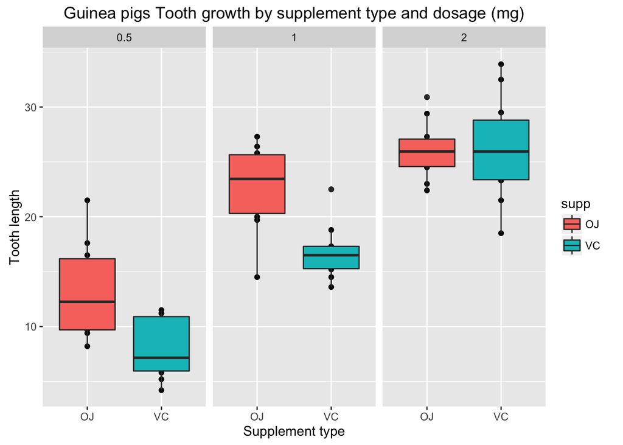

```r
plot <- qplot(supp
              ,len
              ,data=ToothGrowth
              ,facets=~dose
              ,main="Guinea pigs Tooth growth by supplement type and dosage (mg)"
              ,xlab="Supplement type"
              ,ylab="Tooth length")

plot + geom_boxplot(aes(fill = supp))
```

This plot shows that there is an obvius difference in tooth growth depending on the Supplement type and the dose, based on this let’s now create the data assumptions and the hypotesis.

## Hypotesis

Since the guinea pigs are divided into 3 groups each sample group holds less than 30 samples per group, actually 20 per group, so we will create two assumptions about the data:

- Each guinea pig must have been selected randomly and it has not a strong relationship with the other groups
- The data from the observations behavies like is normally distributed

Now let’s split the data regarding the supplement type

```r
OJ = ToothGrowth$len[ToothGrowth$supp == 'OJ']
VC = ToothGrowth$len[ToothGrowth$supp == 'VC']
```

And now let’s try the first Hypotesis test, using a confidence interval of 95%, leaving and error tolerance of 5% with a null hypotesis that both (Orange Juice and Ascorbic Acid) means are equal.

```r
t.test(OJ, VC, alternative = "greater", paired = FALSE, var.equal = FALSE, conf.level = 0.95)
```

```
##
##  Welch Two Sample t-test
##
## data:  OJ and VC
## t = 1.9153, df = 55.309, p-value = 0.03032
## alternative hypothesis: true difference in means is greater than 0
## 95 percent confidence interval:
##  0.4682687       Inf
## sample estimates:
## mean of x mean of y
##  20.66333  16.96333
```

With a p-value of 0.03 been smaller than 5%, the null hypotesis proves to be rejected and the validates the altenative hypotesis. But now we must test against the dose to validate if only the supplement creates a statistical significant difference.

Let create a new hypotesis where we will evaluate the 3 dosis type regardless of the supplement type this time.

```r
dose05mg = ToothGrowth$len[ToothGrowth$dose == 0.5]
dose1mg = ToothGrowth$len[ToothGrowth$dose == 1]
dose2mg = ToothGrowth$len[ToothGrowth$dose == 2]
```

Let’s create two new t tests comparing the 0.5mg dose against the 1 mg dose and then make the a simillar t test between 1 mg and 2 mg.

```r
t.test(dose05mg, dose1mg, alternative = "less", paired = FALSE, var.equal = FALSE, conf.level = 0.95)
```

```
##
##  Welch Two Sample t-test
##
## data:  dose05mg and dose1mg
## t = -6.4766, df = 37.986, p-value = 6.342e-08
## alternative hypothesis: true difference in means is less than 0
## 95 percent confidence interval:
##       -Inf -6.753323
## sample estimates:
## mean of x mean of y
##    10.605    19.735
```

```r
t.test(dose1mg, dose2mg, alternative = "less", paired = FALSE, var.equal = FALSE, conf.level = 0.95)
```

```
##
##  Welch Two Sample t-test
##
## data:  dose1mg and dose2mg
## t = -4.9005, df = 37.101, p-value = 9.532e-06
## alternative hypothesis: true difference in means is less than 0
## 95 percent confidence interval:
##      -Inf -4.17387
## sample estimates:
## mean of x mean of y
##    19.735    26.100
```

And now that there is also evidence that the dose affects the tooth growth, let’s create a final hypotesis to t test the supplement type with the higher dose of Vitamin C.

```r
OJ2 = ToothGrowth$len[ToothGrowth$supp == 'OJ' & ToothGrowth$dose == 2]
VC2 = ToothGrowth$len[ToothGrowth$supp == 'VC' & ToothGrowth$dose == 2]

t.test(OJ2, VC2, alternative = "two.sided", paired = FALSE, var.equal = FALSE, conf.level = 0.95)
```

```
##
##  Welch Two Sample t-test
##
## data:  OJ2 and VC2
## t = -0.046136, df = 14.04, p-value = 0.9639
## alternative hypothesis: true difference in means is not equal to 0
## 95 percent confidence interval:
##  -3.79807  3.63807
## sample estimates:
## mean of x mean of y
##     26.06     26.14
```

## Conclusions

Througth the previous tests we were able to demostrate a statistical significant difference in the tooth growth based on supplements of Vitamin C over Orange Juice or Ascorbic Acid and also showen that the dose of the supplements also affects the length of the tooths.